# Trabalho Statistics Fundamentals - Trab 4

Descrição:

Os sistemas de compartilhamento de bicicletas são uma nova geração de aluguel de bicicletas tradicional, onde todo o processo de associação, locação e devolução tornou-se automático. Através destes sistemas, o usuário pode facilmente alugar uma bicicleta a partir de uma determinada posição e retornar em outra posição. Atualmente, existem cerca de 500 programas de compartilhamento de bicicletas em todo o mundo, compostos por mais de 500 mil bicicletas. Hoje, existe um grande interesse nesses sistemas devido ao seu importante papel no trânsito, questões ambientais e de saúde.

Fonte de dados: https://archive.ics.uci.edu/ml/datasets/Bike+Sharing+Dataset

- Carregando pacotes

```r
#install.packages("corrplot")
library(tidyverse)
library(readr)
library(corrplot)
```

- Carregando a base de dados

```r
ds <- read_csv("Bike_Sharing.csv", show_col_types = FALSE)
options(scipe = 999)
attach(ds)
```

- Acertando o tipo de variável

Variáveis categoricas

```r
ds$season <- as.factor(ds$season)
ds$yr <- as.factor(ds$yr)
ds$holiday <- as.factor(ds$holiday)
ds$weekday <- as.factor(ds$weekday)
ds$workingday <- as.factor(ds$workingday)
ds$weathersit <- as.factor(ds$weathersit)
ds$mnth <- as.factor(ds$mnth)
```

- Apresentando dados estatistico da base de dados

```r
summary(ds)
```

```
    instant          dteday           season  yr           mnth     holiday weekday workingday
 Min.   :  1.0   Min.   :2011-01-01   1:181   0:365   1      : 62   0:710   0:105   0:231
 1st Qu.:183.5   1st Qu.:2011-07-02   2:184   1:366   3      : 62   1: 21   1:105   1:500
 Median :366.0   Median :2012-01-01   3:188           5      : 62           2:104
 Mean   :366.0   Mean   :2012-01-01   4:178           7      : 62           3:104
 3rd Qu.:548.5   3rd Qu.:2012-07-01                   8      : 62           4:104
 Max.   :731.0   Max.   :2012-12-31                   10     : 62           5:104
                                                      (Other):359           6:105
 weathersit      temp             atemp              hum           windspeed           casual
 1:463      Min.   :0.05913   Min.   :0.07907   Min.   :0.0000   Min.   :0.02239   Min.   :   2.0
 2:247      1st Qu.:0.33708   1st Qu.:0.33784   1st Qu.:0.5200   1st Qu.:0.13495   1st Qu.: 315.5
 3: 21      Median :0.49833   Median :0.48673   Median :0.6267   Median :0.18097   Median : 713.0
            Mean   :0.49538   Mean   :0.47435   Mean   :0.6279   Mean   :0.19049   Mean   : 848.2
            3rd Qu.:0.65542   3rd Qu.:0.60860   3rd Qu.:0.7302   3rd Qu.:0.23321   3rd Qu.:1096.0
            Max.   :0.86167   Max.   :0.84090   Max.   :0.9725   Max.   :0.50746   Max.   :3410.0

   registered        cnt
 Min.   :  20   Min.   :  22
 1st Qu.:2497   1st Qu.:3152
 Median :3662   Median :4548
 Mean   :3656   Mean   :4504
 3rd Qu.:4776   3rd Qu.:5956
 Max.   :6946   Max.   :8714
```

- Analisando feriados

No total da amostra, tiveram 21 feriados e 710 dias normais

```r
fa_holiday = table(holiday);fa_holiday
```

```
holiday
  0   1
710  21
```

```r
fr_holiday = fa_holiday/sum(fa_holiday)
dist_holiday = cbind(fa_holiday, fr_holiday);dist_holiday
```

```
  fa_holiday fr_holiday
0        710 0.97127223
1         21 0.02872777
```

- Analisando dias da semana

A nossa amostra tivemos proporção dos dias da semana, contendo assim praticamente uma semana inteira ao longo das observações

```r
fa_weekday = table(weekday);fa_weekday
```

```
weekday
  0   1   2   3   4   5   6
105 105 104 104 104 104 105
```

```r
fr_weekday = fa_weekday/sum(fa_weekday);fr_weekday
```

```
weekday
        0         1         2         3         4         5         6
0.1436389 0.1436389 0.1422709 0.1422709 0.1422709 0.1422709 0.1436389
```

```r
dist_weekday = cbind(fa_weekday, fr_weekday);
dist_weekday
```

```
  fa_weekday fr_weekday
0        105  0.1436389
1        105  0.1436389
2        104  0.1422709
3        104  0.1422709
4        104  0.1422709
5        104  0.1422709
6        105  0.1436389
```

- Analisando dias de trabalho

Pela amostra temos que 500 dias foram de trabalho, e 231 dias de folga

```r
fa_workingday = table(workingday);fa_workingday
```

```
workingday
  0   1
231 500
```

```r
fr_workingday = fa_workingday/sum(fa_workingday);fr_workingday
```

```
workingday
        0         1
0.3160055 0.6839945
```

```r
dist_workingday = cbind(fa_workingday, fr_workingday);
dist_workingday
```

```
  fa_workingday fr_workingday
0           231     0.3160055
1           500     0.6839945
```

- Analisando clima

463 dias foram: Clear, Few clouds, Partly cloudy, Partly cloudy 247 dias foram: Mist + Cloudy, Mist + Broken clouds, Mist + Few clouds, Mist 21 dias foram: Light Snow, Light Rain + Thunderstorm + Scattered clouds, Light Rain + Scattered clouds

e não tivemos nenhuma obseervação sendo Heavy Rain + Ice Pallets + Thunderstorm + Mist, Snow + Fog

```r
fa_weathersit = table(weathersit);fa_weathersit
```

```
weathersit
  1   2   3
463 247  21
```

```r
fr_weathersit = fa_weathersit/sum(fa_weathersit);fr_weathersit
```

```
weathersit
         1          2          3
0.63337893 0.33789330 0.02872777
```

```r
dist_weathersit = cbind(fa_weathersit, fr_weathersit);
dist_weathersit
```

```
  fa_weathersit fr_weathersit
1           463    0.63337893
2           247    0.33789330
3            21    0.02872777
```

- Analisando estação do ano

```r
fa_season = table(season);fa_season
```

```
season
  1   2   3   4
181 184 188 178
```

```r
fr_season = fa_season/sum(fa_season);fr_season
```

```
season
        1         2         3         4
0.2476060 0.2517100 0.2571819 0.2435021
```

```r
dist_season = cbind(fa_season, fr_season);
dist_season
```

```
  fa_season fr_season
1       181 0.2476060
2       184 0.2517100
3       188 0.2571819
4       178 0.2435021
```

- Aplicando a correlação de Pearson

As variáveis que possuem uma correlação com a variável target cnt são temp e atemp. Estas correlações são positivas mas com média correlação.

Já hum e windspeed tem correlação negativa bem fraca.

```r
dadosquant <- select_if(ds, is.numeric)
dadosquant <- subset(dadosquant, select=c(cnt,temp,atemp, hum, windspeed))
mc = cor(dadosquant); mc
```

```
                 cnt       temp      atemp        hum  windspeed
cnt        1.0000000  0.6274940  0.6310657 -0.1006586 -0.2345450
temp       0.6274940  1.0000000  0.9917016  0.1269629 -0.1579441
atemp      0.6310657  0.9917016  1.0000000  0.1399881 -0.1836430
hum       -0.1006586  0.1269629  0.1399881  1.0000000 -0.2484891
windspeed -0.2345450 -0.1579441 -0.1836430 -0.2484891  1.0000000
```

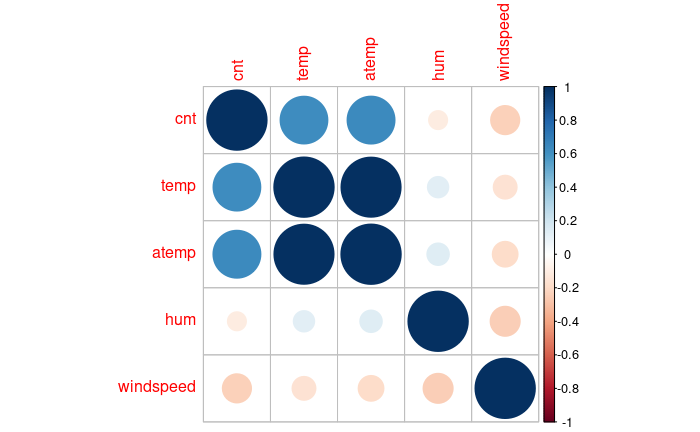

```r
corrplot(mc)
```

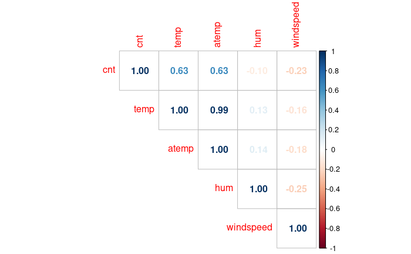

```r
corrplot(mc, type="upper", method = "number")
```

- Preparando a base para modar um modelo de regressão linear multipla
- Apagando variáveis

```r
ds$instant = NULL
ds$dteday = NULL
ds$casual = NULL
ds$registered = NULL
ds$fx_cont = NULL
ds
```

| season | yr | mnth | holiday | weekday | workingday | weathersit | temp | atemp | hum | windspeed | cnt |
| --- | --- | --- | --- | --- | --- | --- | --- | --- | --- | --- | --- |
| 1 | 0 | 1 | 0 | 6 | 0 | 2 | 0.3441670 | 0.3636250 | 0.805833 | 0.1604460 | 985 |
| 1 | 0 | 1 | 0 | 0 | 0 | 2 | 0.3634780 | 0.3537390 | 0.696087 | 0.2485390 | 801 |
| 1 | 0 | 1 | 0 | 1 | 1 | 1 | 0.1963640 | 0.1894050 | 0.437273 | 0.2483090 | 1349 |
| 1 | 0 | 1 | 0 | 2 | 1 | 1 | 0.2000000 | 0.2121220 | 0.590435 | 0.1602960 | 1562 |
| 1 | 0 | 1 | 0 | 3 | 1 | 1 | 0.2269570 | 0.2292700 | 0.436957 | 0.1869000 | 1600 |
| 1 | 0 | 1 | 0 | 4 | 1 | 1 | 0.2043480 | 0.2332090 | 0.518261 | 0.0895652 | 1606 |
| 1 | 0 | 1 | 0 | 5 | 1 | 2 | 0.1965220 | 0.2088390 | 0.498696 | 0.1687260 | 1510 |
| 1 | 0 | 1 | 0 | 6 | 0 | 2 | 0.1650000 | 0.1622540 | 0.535833 | 0.2668040 | 959 |
| 1 | 0 | 1 | 0 | 0 | 0 | 1 | 0.1383330 | 0.1161750 | 0.434167 | 0.3619500 | 822 |
| 1 | 0 | 1 | 0 | 1 | 1 | 1 | 0.1508330 | 0.1508880 | 0.482917 | 0.2232670 | 1321 |

[output cut: 721 more lines]

- Criando variáveis dicotômicas com variável qualitativa

```r
#ds$season1 = season
#ds$season1 = ifelse(season==1,"1","0")
ds$season2 = season
ds$season2 = ifelse(season==2,"1","0")
ds$season3 = season
ds$season3 = ifelse(season==3,"1","0")
ds$season4 = season
ds$season4 = ifelse(season==4,"1","0")

#ds$weathersit1 = weathersit
#ds$weathersit1 = ifelse(weathersit==1,"1","0")
ds$weathersit2 = weathersit
ds$weathersit2 = ifelse(weathersit==2,"1","0")
ds$weathersit3 = weathersit
ds$weathersit3 = ifelse(weathersit==3,"1","0")

#ds$mnth1 = mnth
#ds$mnth1 = ifelse(mnth==1,"1","0")
ds$mnth2 = mnth
ds$mnth2 = ifelse(mnth==2,"1","0")
ds$mnth3 = mnth
ds$mnth3 = ifelse(mnth==3,"1","0")
ds$mnth4 = mnth
ds$mnth4 = ifelse(mnth==4,"1","0")
ds$mnth5 = mnth
ds$mnth5 = ifelse(mnth==5,"1","0")
ds$mnth6 = mnth
ds$mnth6 = ifelse(mnth==6,"1","0")
ds$mnth7 = mnth
ds$mnth7 = ifelse(mnth==7,"1","0")
ds$mnth8 = mnth
ds$mnth8 = ifelse(mnth==8,"1","0")
ds$mnth9 = mnth
ds$mnth9 = ifelse(mnth==9,"1","0")
ds$mnth10 = mnth
ds$mnth10 = ifelse(mnth==10,"1","0")
ds$mnth11 = mnth
ds$mnth11 = ifelse(mnth==11,"1","0")
ds$mnth12 = mnth
ds$mnth12 = ifelse(mnth==12,"1","0")
```

Apagando mais variáveis

```r
ds$season = NULL
ds$mnth = NULL
ds$weathersit = NULL
ds$weekday = NULL
ds$temp_atemp = NULL
```

Modelo

- Dividindo amostra de treino e validação

```r
set.seed(2021)
train <- sample(nrow(ds), 0.7*nrow(ds), replace=FALSE)
TrainSet <- ds[train,]
ValidSet <- ds[-train,]

attach(TrainSet)
```

- Criando Modelo

```r
modelo <-lm(cnt ~ . , data = TrainSet)
summary(modelo)
```

```
Call:
lm(formula = cnt ~ ., data = TrainSet)

Residuals:
    Min      1Q  Median      3Q     Max
-3824.4  -346.7   108.0   467.3  3015.2

Coefficients:
              Estimate Std. Error t value Pr(>|t|)
(Intercept)   1797.381    281.142   6.393 3.81e-10 ***
yr1           2027.351     74.133  27.347  < 2e-16 ***
holiday1      -804.330    231.921  -3.468 0.000571 ***
workingday1     96.377     81.105   1.188 0.235297
temp          3982.145   1572.916   2.532 0.011665 *
atemp         1050.806   1626.108   0.646 0.518448
hum          -1805.708    361.707  -4.992 8.33e-07 ***
windspeed    -3079.257    515.991  -5.968 4.64e-09 ***
season21       902.023    205.616   4.387 1.41e-05 ***
season31       770.350    259.942   2.964 0.003190 **
season41      1400.440    235.622   5.944 5.32e-09 ***
weathersit21  -386.642     96.521  -4.006 7.15e-05 ***
weathersit31 -1853.753    256.888  -7.216 2.06e-12 ***
mnth21          94.053    182.944   0.514 0.607411
mnth31         510.229    201.042   2.538 0.011462 *
mnth41         377.324    304.803   1.238 0.216340
mnth51         660.040    326.319   2.023 0.043651 *
mnth61         335.170    342.275   0.979 0.327947
mnth71         -97.512    390.398  -0.250 0.802866
mnth81         307.193    375.319   0.818 0.413480
mnth91         940.640    329.915   2.851 0.004541 **
mnth101        539.277    312.253   1.727 0.084793 .
mnth111         -9.596    297.920  -0.032 0.974317
mnth121         22.330    240.322   0.093 0.926009
---
Signif. codes:  0 ‘***’ 0.001 ‘**’ 0.01 ‘*’ 0.05 ‘.’ 0.1 ‘ ’ 1

Residual standard error: 810.7 on 487 degrees of freedom
Multiple R-squared:  0.8357,    Adjusted R-squared:  0.8279
F-statistic: 107.7 on 23 and 487 DF,  p-value: < 2.2e-16
```

- Selecionando melhores variáveis
- Pegando as variáveis mais significativas

```r
modelo_stepwise <- step(modelo, direction = "both")
```

```
Start:  AIC=6868.63
cnt ~ yr + holiday + workingday + temp + atemp + hum + windspeed +
    season2 + season3 + season4 + weathersit2 + weathersit3 +
    mnth2 + mnth3 + mnth4 + mnth5 + mnth6 + mnth7 + mnth8 + mnth9 +
    mnth10 + mnth11 + mnth12

              Df Sum of Sq       RSS    AIC
- mnth11       1       682 320051971 6866.6
- mnth12       1      5674 320056963 6866.6
- mnth7        1     41001 320092290 6866.7
- mnth2        1    173699 320224988 6866.9
- atemp        1    274434 320325723 6867.1
- mnth8        1    440264 320491554 6867.3
- mnth6        1    630188 320681477 6867.6
- workingday   1    927979 320979269 6868.1
- mnth4        1   1007117 321058407 6868.2
<none>                     320051290 6868.6
- mnth10       1   1960199 322011488 6869.8
- mnth5        1   2688733 322740023 6870.9
- temp         1   4212248 324263537 6873.3
- mnth3        1   4232988 324284277 6873.3
- mnth9        1   5342366 325393656 6875.1
- season3      1   5771823 325823113 6875.8
- holiday      1   7904578 327955867 6879.1
- weathersit2  1  10545507 330596796 6883.2
- season2      1  12647763 332699052 6886.4
- hum          1  16378364 336429653 6892.1
- season4      1  23215996 343267286 6902.4
- windspeed    1  23404433 343455722 6902.7
- weathersit3  1  34222220 354273510 6918.5
- yr           1 491499301 811550590 7342.1

Step:  AIC=6866.64
cnt ~ yr + holiday + workingday + temp + atemp + hum + windspeed +
    season2 + season3 + season4 + weathersit2 + weathersit3 +
    mnth2 + mnth3 + mnth4 + mnth5 + mnth6 + mnth7 + mnth8 + mnth9 +
    mnth10 + mnth12

              Df Sum of Sq       RSS    AIC
- mnth12       1     21321 320073293 6864.7
```

[output cut: 164 more lines]

```
- mnth8        1   3259063 324917459 6862.3
- mnth5        1   5555872 327214268 6865.9
- mnth10       1   7125705 328784101 6868.4
- season3      1   7432109 329090505 6868.9
- mnth3        1   7526309 329184705 6869.0
- holiday      1  10384243 332042639 6873.4
- weathersit2  1  10600622 332259018 6873.8
- season2      1  14238578 335896974 6879.3
- hum          1  16538705 338197101 6882.8
- windspeed    1  25930637 347589033 6896.8
- mnth9        1  26503378 348161774 6897.7
- weathersit3  1  34063716 355722112 6908.6
- season4      1  71526932 393185328 6959.8
- temp         1  99568251 421226647 6995.0
- yr           1 498963304 820621700 7335.8
```

```r
summary(modelo_stepwise)
```

```
Call:
lm(formula = cnt ~ yr + holiday + temp + hum + windspeed + season2 +
    season3 + season4 + weathersit2 + weathersit3 + mnth3 + mnth4 +
    mnth5 + mnth6 + mnth8 + mnth9 + mnth10, data = TrainSet)

Residuals:
    Min      1Q  Median      3Q     Max
-3809.6  -350.9   122.6   486.6  2931.9

Coefficients:
             Estimate Std. Error t value Pr(>|t|)
(Intercept)   1936.74     261.20   7.415 5.36e-13 ***
yr1           2028.47      73.35  27.654  < 2e-16 ***
holiday1      -885.06     221.85  -3.989 7.63e-05 ***
temp          4893.14     396.10  12.353  < 2e-16 ***
hum          -1772.88     352.13  -5.035 6.72e-07 ***
windspeed    -3161.94     501.56  -6.304 6.44e-10 ***
season21       864.99     185.16   4.672 3.86e-06 ***
season31       667.96     197.91   3.375 0.000796 ***
season41      1366.57     130.52  10.470  < 2e-16 ***
weathersit21  -384.46      95.38  -4.031 6.44e-05 ***
weathersit31 -1843.07     255.08  -7.226 1.91e-12 ***
mnth31         497.47     146.47   3.396 0.000738 ***
mnth41         384.30     228.18   1.684 0.092772 .
mnth51         672.05     230.30   2.918 0.003682 **
mnth61         370.42     191.92   1.930 0.054178 .
mnth81         370.24     165.66   2.235 0.025866 *
mnth91         995.02     156.12   6.373 4.25e-10 ***
mnth101        538.32     162.89   3.305 0.001020 **
---
Signif. codes:  0 ‘***’ 0.001 ‘**’ 0.01 ‘*’ 0.05 ‘.’ 0.1 ‘ ’ 1

Residual standard error: 807.7 on 493 degrees of freedom
Multiple R-squared:  0.8348,    Adjusted R-squared:  0.8291
F-statistic: 146.6 on 17 and 493 DF,  p-value: < 2.2e-16
```

- Predizendo e criando residuo

```r
TrainSet$Val_pred <- predict(modelo_stepwise, interval = "prediction", level = 0.95)
TrainSet$residuo <- resid(modelo_stepwise)
TrainSet$rp <- rstandard(modelo_stepwise)
```

- Calculando o erro do modelo

```r
mse <- mean((TrainSet$cnt - TrainSet$Val_pred)^2)
mse
```

```
[1] 2367760
```

- Verificando atraves do teste de Shapiro se os erros seguem ou não uma distribuição normal, e se ele tem outliers

```r
shapiro.test(residuals(modelo_stepwise))
```

```
    Shapiro-Wilk normality test

data:  residuals(modelo_stepwise)
W = 0.94884, p-value = 2.714e-12
```

- Aplicando um novo conjunto de teste para criação do modelo

```r
TrainSetNovo <- filter(TrainSet, TrainSet$rp >=-2& TrainSet$rp<=2)
```

- Apagando colunas criadas ao executar modelo

```r
TrainSetNovo$Val_pred = NULL
TrainSetNovo$residuo = NULL
TrainSetNovo$rp = NULL
```

- Criando modelo

```r
modeloNovo = lm(cnt ~ ., data = TrainSetNovo)
summary(modeloNovo)
```

```
Call:
lm(formula = cnt ~ ., data = TrainSetNovo)

Residuals:
     Min       1Q   Median       3Q      Max
-1647.91  -370.64    49.61   400.56  1541.38

Coefficients:
             Estimate Std. Error t value Pr(>|t|)
(Intercept)   1703.11     214.33   7.946 1.50e-14 ***
yr1           2151.75      57.39  37.494  < 2e-16 ***
holiday1      -879.24     187.81  -4.682 3.75e-06 ***
workingday1     72.81      63.46   1.147 0.251854
temp          2786.27    1203.22   2.316 0.021016 *
atemp         1747.27    1240.37   1.409 0.159608
hum          -1512.40     276.97  -5.461 7.79e-08 ***
windspeed    -2826.34     403.67  -7.002 9.04e-12 ***
season21       757.28     160.47   4.719 3.15e-06 ***
season31       650.55     203.50   3.197 0.001485 **
season41      1301.21     186.69   6.970 1.11e-11 ***
weathersit21  -434.14      73.54  -5.904 6.92e-09 ***
weathersit31 -1667.46     198.05  -8.419 4.88e-16 ***
mnth21          85.40     138.02   0.619 0.536389
mnth31         530.80     153.80   3.451 0.000610 ***
mnth41         608.59     237.54   2.562 0.010724 *
mnth51         989.31     255.29   3.875 0.000122 ***
mnth61         813.93     270.67   3.007 0.002783 **
mnth71         379.45     310.38   1.223 0.222128
mnth81         743.91     298.78   2.490 0.013134 *
mnth91        1167.91     262.09   4.456 1.05e-05 ***
mnth101        923.86     248.92   3.712 0.000231 ***
mnth111        305.89     235.16   1.301 0.193999
mnth121        193.73     192.14   1.008 0.313862
---
Signif. codes:  0 ‘***’ 0.001 ‘**’ 0.01 ‘*’ 0.05 ‘.’ 0.1 ‘ ’ 1

Residual standard error: 605.7 on 459 degrees of freedom
Multiple R-squared:  0.9053,    Adjusted R-squared:  0.9005
F-statistic: 190.7 on 23 and 459 DF,  p-value: < 2.2e-16
```

- Modelo novo com variáveis significativas

```r
modeloNovo_stepwise <- step(modeloNovo, direction = "both")
```

```
Start:  AIC=6211.89
cnt ~ yr + holiday + workingday + temp + atemp + hum + windspeed +
    season2 + season3 + season4 + weathersit2 + weathersit3 +
    mnth2 + mnth3 + mnth4 + mnth5 + mnth6 + mnth7 + mnth8 + mnth9 +
    mnth10 + mnth11 + mnth12

              Df Sum of Sq       RSS    AIC
- mnth2        1    140440 168514606 6210.3
- mnth12       1    372911 168747077 6211.0
- workingday   1    482858 168857024 6211.3
- mnth7        1    548270 168922436 6211.5
- mnth11       1    620648 168994814 6211.7
<none>                     168374166 6211.9
- atemp        1    727924 169102090 6212.0
- temp         1   1967055 170341221 6215.5
- mnth8        1   2274045 170648211 6216.4
- mnth4        1   2407871 170782037 6216.8
- mnth6        1   3316998 171691164 6219.3
- season3      1   3748939 172123105 6220.5
- mnth3        1   4369156 172743322 6222.3
- mnth10       1   5053191 173427356 6224.2
- mnth5        1   5508654 173882820 6225.4
- mnth9        1   7284330 175658496 6230.3
- holiday      1   8039812 176413977 6232.4
- season2      1   8169296 176543462 6232.8
- hum          1  10937749 179311915 6240.3
- weathersit2  1  12785510 181159675 6245.2
- season4      1  17820594 186194759 6258.5
- windspeed    1  17982866 186357031 6258.9
- weathersit3  1  26002134 194376300 6279.3
- yr           1 515690647 684064813 6887.0

Step:  AIC=6210.3
cnt ~ yr + holiday + workingday + temp + atemp + hum + windspeed +
    season2 + season3 + season4 + weathersit2 + weathersit3 +
    mnth3 + mnth4 + mnth5 + mnth6 + mnth7 + mnth8 + mnth9 + mnth10 +
    mnth11 + mnth12

              Df Sum of Sq       RSS    AIC
- mnth12       1    262130 168776736 6209.0
```

[output cut: 134 more lines]

```
- mnth8        1   3456975 173018184 6213.0
- mnth6        1   4248355 173809564 6215.2
- mnth3        1   4556505 174117714 6216.1
- mnth5        1   6273184 175834394 6220.8
- mnth10       1   8710371 178271580 6227.5
- season3      1   9782337 179343547 6230.4
- holiday      1   9817134 179378343 6230.5
- hum          1  11884420 181445629 6236.0
- weathersit2  1  12527285 182088494 6237.7
- season2      1  12553738 182114947 6237.8
- mnth9        1  17772867 187334076 6251.4
- windspeed    1  18739679 188300889 6253.9
- weathersit3  1  25726646 195287855 6271.5
- season4      1  77206084 246767293 6384.5
- yr           1 518880641 688441851 6880.1
```

```r
summary(modeloNovo_stepwise)
```

```
Call:
lm(formula = cnt ~ yr + holiday + temp + atemp + hum + windspeed +
    season2 + season3 + season4 + weathersit2 + weathersit3 +
    mnth3 + mnth4 + mnth5 + mnth6 + mnth8 + mnth9 + mnth10, data = TrainSetNovo)

Residuals:
     Min       1Q   Median       3Q      Max
-1740.42  -369.71    45.01   419.65  1495.06

Coefficients:
             Estimate Std. Error t value Pr(>|t|)
(Intercept)   1759.51     204.29   8.613  < 2e-16 ***
yr1           2145.45      56.94  37.682  < 2e-16 ***
holiday1      -931.36     179.69  -5.183 3.26e-07 ***
temp          3111.45    1159.55   2.683 0.007550 **
atemp         1730.81    1235.01   1.401 0.161747
hum          -1539.71     269.99  -5.703 2.10e-08 ***
windspeed    -2854.50     398.61  -7.161 3.16e-12 ***
season21       845.06     144.18   5.861 8.73e-09 ***
season31       794.90     153.64   5.174 3.42e-07 ***
season41      1464.27     100.74  14.535  < 2e-16 ***
weathersit21  -426.39      72.83  -5.855 9.04e-09 ***
weathersit31 -1655.08     197.26  -8.390 5.89e-16 ***
mnth31         396.48     112.28   3.531 0.000455 ***
mnth41         385.08     176.12   2.186 0.029282 *
mnth51         740.93     178.83   4.143 4.07e-05 ***
mnth61         519.81     152.46   3.410 0.000707 ***
mnth81         402.62     130.90   3.076 0.002224 **
mnth91         852.19     122.20   6.974 1.07e-11 ***
mnth101        622.66     127.54   4.882 1.45e-06 ***
---
Signif. codes:  0 ‘***’ 0.001 ‘**’ 0.01 ‘*’ 0.05 ‘.’ 0.1 ‘ ’ 1

Residual standard error: 604.5 on 464 degrees of freedom
Multiple R-squared:  0.9046,    Adjusted R-squared:  0.9009
F-statistic: 244.4 on 18 and 464 DF,  p-value: < 2.2e-16
```

- Predizendo e criando residuo

```r
TrainSetNovo$Val_pred <- predict(modeloNovo_stepwise, interval = "prediction", level = 0.95)
TrainSetNovo$residuo <- resid(modeloNovo_stepwise)
TrainSetNovo$rp <- rstandard(modeloNovo_stepwise)
```

- Calculando o erro do modelo

```r
mseNovo <- mean((TrainSetNovo$cnt - TrainSetNovo$Val_pred)^2)
sqrt(mseNovo)
```

```
[1] 1152.75
```

Modelo final

```r
summary(modeloNovo_stepwise)
```

```
Call:
lm(formula = cnt ~ yr + holiday + temp + atemp + hum + windspeed +
    season2 + season3 + season4 + weathersit2 + weathersit3 +
    mnth3 + mnth4 + mnth5 + mnth6 + mnth8 + mnth9 + mnth10, data = TrainSetNovo)

Residuals:
     Min       1Q   Median       3Q      Max
-1740.42  -369.71    45.01   419.65  1495.06

Coefficients:
             Estimate Std. Error t value Pr(>|t|)
(Intercept)   1759.51     204.29   8.613  < 2e-16 ***
yr1           2145.45      56.94  37.682  < 2e-16 ***
holiday1      -931.36     179.69  -5.183 3.26e-07 ***
temp          3111.45    1159.55   2.683 0.007550 **
atemp         1730.81    1235.01   1.401 0.161747
hum          -1539.71     269.99  -5.703 2.10e-08 ***
windspeed    -2854.50     398.61  -7.161 3.16e-12 ***
season21       845.06     144.18   5.861 8.73e-09 ***
season31       794.90     153.64   5.174 3.42e-07 ***
season41      1464.27     100.74  14.535  < 2e-16 ***
weathersit21  -426.39      72.83  -5.855 9.04e-09 ***
weathersit31 -1655.08     197.26  -8.390 5.89e-16 ***
mnth31         396.48     112.28   3.531 0.000455 ***
mnth41         385.08     176.12   2.186 0.029282 *
mnth51         740.93     178.83   4.143 4.07e-05 ***
mnth61         519.81     152.46   3.410 0.000707 ***
mnth81         402.62     130.90   3.076 0.002224 **
mnth91         852.19     122.20   6.974 1.07e-11 ***
mnth101        622.66     127.54   4.882 1.45e-06 ***
---
Signif. codes:  0 ‘***’ 0.001 ‘**’ 0.01 ‘*’ 0.05 ‘.’ 0.1 ‘ ’ 1

Residual standard error: 604.5 on 464 degrees of freedom
Multiple R-squared:  0.9046,    Adjusted R-squared:  0.9009
F-statistic: 244.4 on 18 and 464 DF,  p-value: < 2.2e-16
```

Conclusão do trabalho

Conseguimos chegar em uma formula de regressão linear, com isto podemos passar os parametros para o modelo e iriamos conseguir predizer a quantidade de bike necessárias no dia.

A formula final do model é:

y = Bo + B1 * x1 + B2 * x2…

y = 1759,51 + yr1 * 2145,45 + holiday1 * -931,36 + temp * 3111,45 + atemp * 1730,81 + hum * -1539,71 + windspeed * -2854,5 + season21 * 845,06 + season31 * 794,9 + season41 * 1464,27 + weathersit21 * -426,39 + weathersit31 * -1655,08 + mnth31 * 396,48 + mnth41 * 385,08 + mnth51 * 740,93 + mnth61 * 519,81 + mnth81 * 402,62 + mnth91 * 852,19 + mnth101 * 622,66